# GLM-examples

# Models for proportion: Binomial GLMs

## Examples

- A study produced similar symptoms by exposing volunteers’ lower bodies to negative air pressure, likewise decreasing oxygen to the brain. The data record the ages of eight volunteers and whether they showed syncopal blackout-related signs (pallor, sweating, slow heartbeat, unconsciousness) during an 18 min period. Does resistance to blackout decrease with age?
  - The explanatory variable is Age. The response variable is Signs, coded as 1 if the subject showed blackout-related signs and 0 otherwise. The response variable is binary, taking only two distinct values, and no transformation can change that.
- Second example, the response variable is the number of damaged O-rings out of six for each of the previous 23 launches with data available, so only seven values are possible for the response. No transformation can change this.
- Rather than linear regression, a more sensible model would be to use a binomial distribution with mean proportion $\mu$ for modelling the **proportion** $y$ of O-rings damaged out of m at various temperatures x.

$$\log \frac{\mu}{1-\mu}=\beta_0+\beta_1x$$
combining the systematic and random components, a possible model for the data is:
$$\begin{cases}
ym \sim \text{Bin}(\mu,m) \quad &(\text{random component})\\
\log \frac{\mu}{1-\mu}=\beta_0+\beta_1x \quad &(\text{systematic
component})
\end{cases}$$

## Binomial PMF in EDM form

$$\mathcal{P}(y|\mu, m)={m \choose my}\mu^{my}(1-\mu)^{m(1-y)}$$

where $m$ is known and $\phi=1, 0<\mu<1$. For binomial GLMs, the use of quantile residuals is strongly recommended for diagnostic analysis.

Binomial responses may be specified in the `glm()` formula in one of three ways:

- The response can be supplied as the observed proportions $y_i$, when the sample sizes $m_i$ are supplied as the weights in the call to `glm()`.
- The response can be given as a two-column array, the columns giving the numbers of successes and failures respectively in each group of size $m_i$. The prior weights `weights` do not need to be supplied.
- The response can be given as a factor or as a logicals. This specification is useful if the data have one row for each observation.

```r
library(GLMsData)
data(turbines)

tur.m1 <- glm( Fissures/Turbines ~ Hours, family=binomial,
               weights=Turbines, data=turbines)
tur.m2 <- glm( cbind(Fissures, Turbines-Fissures) ~ Hours,
               family=binomial, data=turbines)
coef(tur.m1)
```

```
##   (Intercept)         Hours
## -3.9235965551  0.0009992372
```

```r
coef(tur.m2)
```

```
##   (Intercept)         Hours
## -3.9235965551  0.0009992372
```

## Link Functions

- logit link function, which is the canonical link function for the binomial distribution and the default link function in R:

$$\eta=\log \frac{\mu}{1-\mu}=logit(\mu)$$

- probit link function: $\eta=\Phi^{-1}(\mu)=probit(\mu)$, where $\Phi(\cdot)$ is the CDF for the normal distribution. This link function is specified in R as `link="probit`.
- complementary log-log link function: $\eta=\log \{-\log (1-\mu)\}$, specified as `link="cloglog"`.

```r
tr.logit <- glm( Fissures/Turbines ~ Hours, data=turbines,
                 family=binomial, weights=Turbines)
tr.probit <- update( tr.logit, family=binomial(link="probit") )
tr.cll <- update( tr.logit, family=binomial(link="cloglog") )
tr.array <- rbind( coef(tr.logit), coef(tr.probit), coef(tr.cll))
tr.array <- cbind( tr.array,
                   c(deviance(tr.logit),
                     deviance(tr.probit),
                     deviance(tr.cll)) )
colnames(tr.array) <- c("Intercept", "Hours","Residual dev.")
rownames(tr.array) <- c("Logit","Probit","Comp log-log")
tr.array
```

```
##              Intercept        Hours Residual dev.
## Logit        -3.923597 0.0009992372     10.331466
## Probit       -2.275807 0.0005783211      9.814837
## Comp log-log -3.603280 0.0008104936     12.227914
```

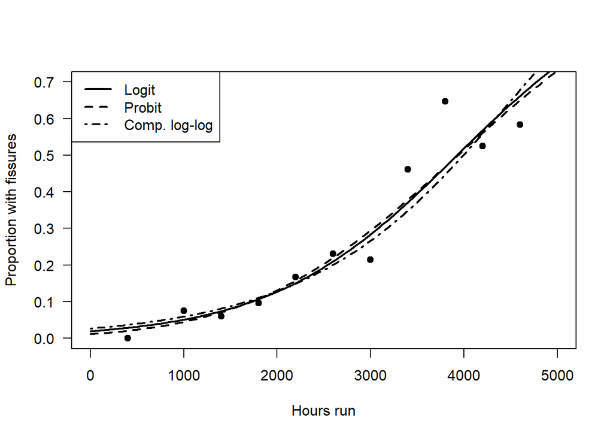

```r
newHrs <- seq( 0, 5000, length=100)
newdf <- data.frame(Hours=newHrs)
newP.logit <- predict( tr.logit, newdata=newdf, type="response")
newP.probit <- predict( tr.probit, newdata=newdf, type="response")
newP.cll <- predict( tr.cll, newdata=newdf, type="response")

plot( Fissures/Turbines ~ Hours, data=turbines, pch=19, las=1,
xlim=c(0, 5000), ylim=c(0, 0.7),
xlab="Hours run", ylab="Proportion with fissures")
lines( newP.logit ~ newHrs, lty=1, lwd=2)
lines( newP.probit ~ newHrs, lty=2, lwd=2)
lines( newP.cll ~ newHrs, lty=4, lwd=2)
legend("topleft", lwd=2, lty=c(1, 2, 4),
legend=c("Logit","Probit","Comp. log-log"))
```

## Odds, Odds Ratios & Logit Link

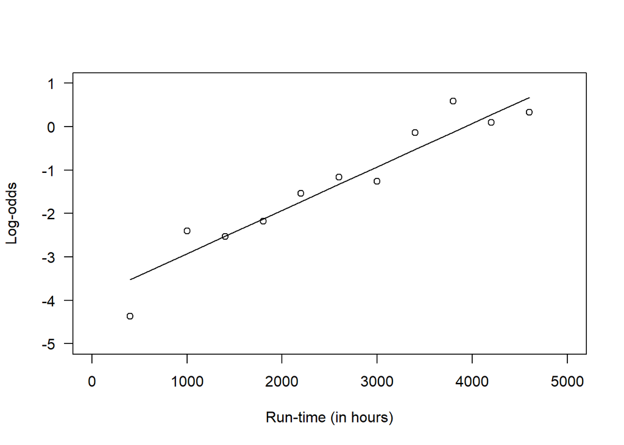

```r
LogOdds <- predict( tr.logit )
odds <- exp( LogOdds )
plot( LogOdds ~ turbines$Hours, type="l", las=1,
      xlim=c(0, 5000), ylim=c(-5, 1),
      ylab="Log-odds", xlab="Run-time (in hours)" )
my <- turbines$Fissures
m <- turbines$Turbines
EmpiricalOdds <- (my + 0.5)/(m - my + 0.5) # empirical log-odds: avoid log of 0s
points( log(EmpiricalOdds) ~ turbines$Hours)
```

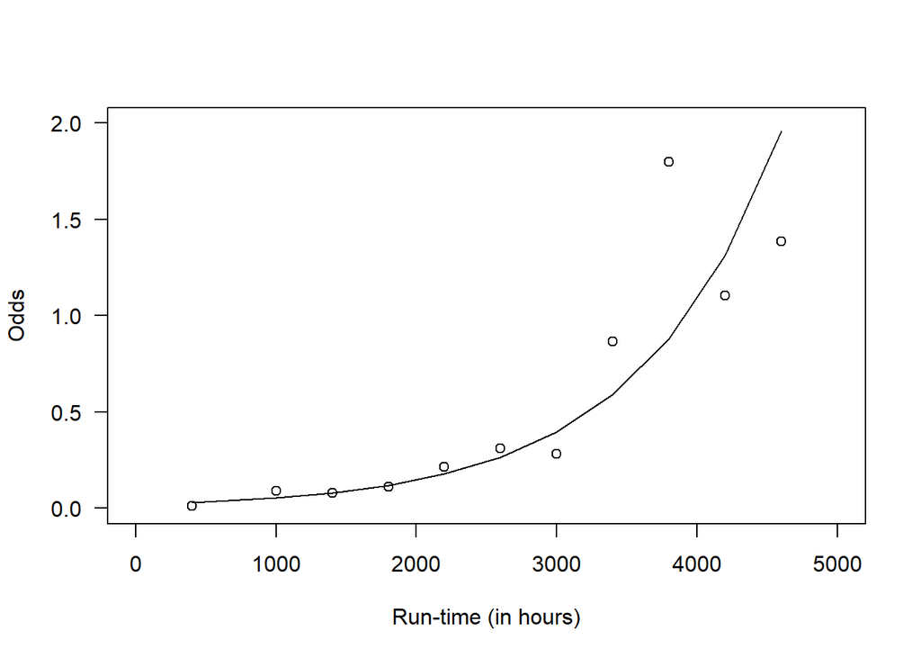

```r
plot( odds ~ turbines$Hours, las=1, xlim=c(0, 5000), ylim=c(0, 2),
      type="l", ylab="Odds", xlab="Run-time (in hours)")
points( EmpiricalOdds ~ turbines$Hours)
```

$$\log \frac{\mu}{1-\mu}=\log-\text{odds}=\beta_0+\beta_1x$$

where x is a dummy variable taking the values 0 or 1. From this equation, we see that the odds of observing a success when $x = 0$ is $\exp(\beta_0)$, and the odds of observing a success when $x = 1$ is $\exp(β0 + β1) = \exp(\beta_0) \exp(\beta_1)$. The ratio of these two odds is $\exp(\beta_1)$. This means that the odds of a success occurring when $x = 1$ is $\exp(\beta_1)$ times greater than when $x = 0$. This ratio is called the `odds ratio`, often written OR.

## Median Effective Dose: ED50

Binomial GLMs are commonly used to examine the relationship between the dose d of a drug or poison and the proportion y of insects (or plants, or animals) that survive. These models are called dose-response models. ED50: the dose of poison affecting 50% of the insects. By definition, $\mu=0.5$ at the ED50. For a binomial GLM using logit link function, $\eta=\log(\mu/(1-\mu))=0$ when $\mu=0.5$, where $\eta=\beta_0+\beta_1d$ and d is the dose. Solving for dose d gives that ED50 $=-\hat{\beta_0}/\hat{\beta_1}$.

## Overdispersion

For a binomial distribution, var$[y]=\mu(1-\mu)$. In practice the amount of variation in the data can exceed this value, which is called `overdispersion`. Consequences are standard errors by GLM are underestimated, and tests on predictors will generally be more significant leading to overly complex models.

Overdispersion can be detected by goodness-of-fit test. Lack of fit may be caused by an inaqdequate model. But if all possible predictors are already in the model and no outliers exist when lack of fit persists ,then overdispersion is the alternative interpretation.

Overdispersion arises in two cases: the probabilities $\mu_i$ are not constant between observations; the $m_i$ cases, of which observations $y_i$ is a proportion, are not independent.

Quasi-binomial GLMs are the remedies for overdispersion.

Example: Since seedsare usually planted together in common plots, it is highly possible that they might interact or be affected by common causes; in other words we might well expect seeds to be positively correlated, leading to overdispersion.

```r
data(germ)
gm.m1 <- glm(Germ/Total ~ Seeds * Extract, family=binomial,
             data=germ, weights=Total)
printCoefmat(coef(summary(gm.m1)))
```

```
##                           Estimate Std. Error z value Pr(>|z|)
## (Intercept)               -0.41224    0.18418 -2.2383  0.02520 *
## SeedsOA75                 -0.14593    0.22317 -0.6539  0.51318
## ExtractCucumber            0.54008    0.24981  2.1619  0.03062 *
## SeedsOA75:ExtractCucumber  0.77810    0.30643  2.5392  0.01111 *
## ---
## Signif. codes:  0 '***' 0.001 '**' 0.01 '*' 0.05 '.' 0.1 ' ' 1
```

```r
anova(gm.m1, test="Chisq")
```

```
## Analysis of Deviance Table
##
## Model: binomial, link: logit
##
## Response: Germ/Total
##
## Terms added sequentially (first to last)
##
##
##               Df Deviance Resid. Df Resid. Dev Pr(>Chi)
## NULL                             20     98.719
## Seeds          1    2.544        19     96.175  0.11070
## Extract        1   56.489        18     39.686 5.65e-14 ***
## Seeds:Extract  1    6.408        17     33.278  0.01136 *
## ---
## Signif. codes:  0 '***' 0.001 '**' 0.01 '*' 0.05 '.' 0.1 ' ' 1
```

```r
df.residual(gm.m1)
```

```
## [1] 17
```

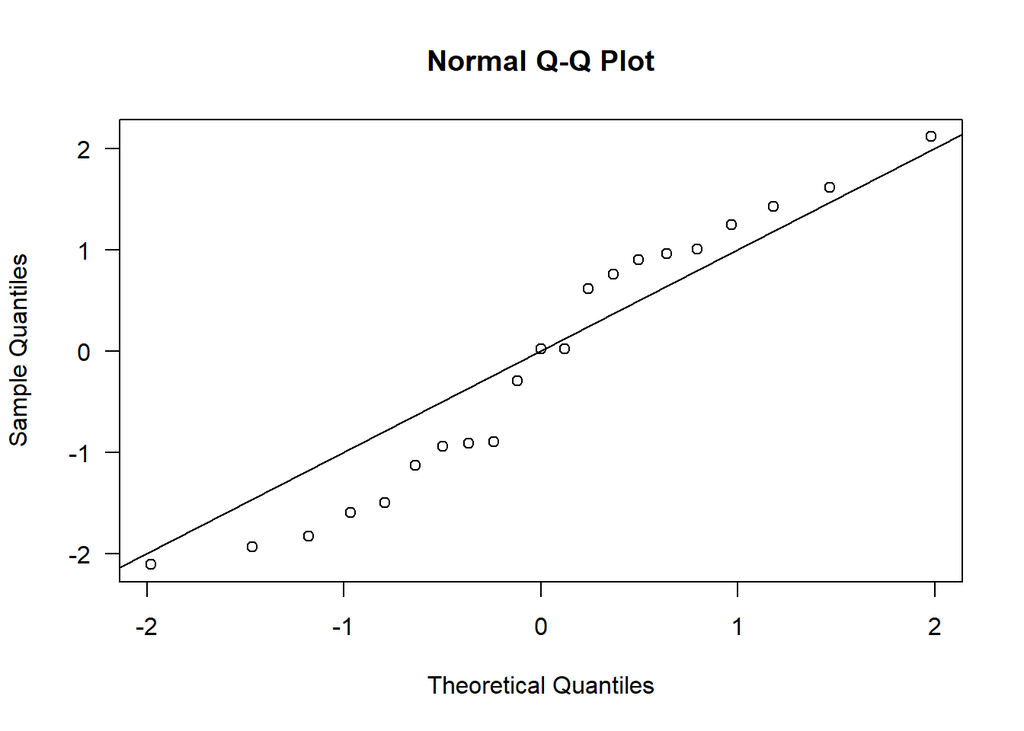

```r
# diagnostic plot
require(statmod)
qres <- qresid(gm.m1)
qqnorm(qres, las=1)
abline(0, 1)
```

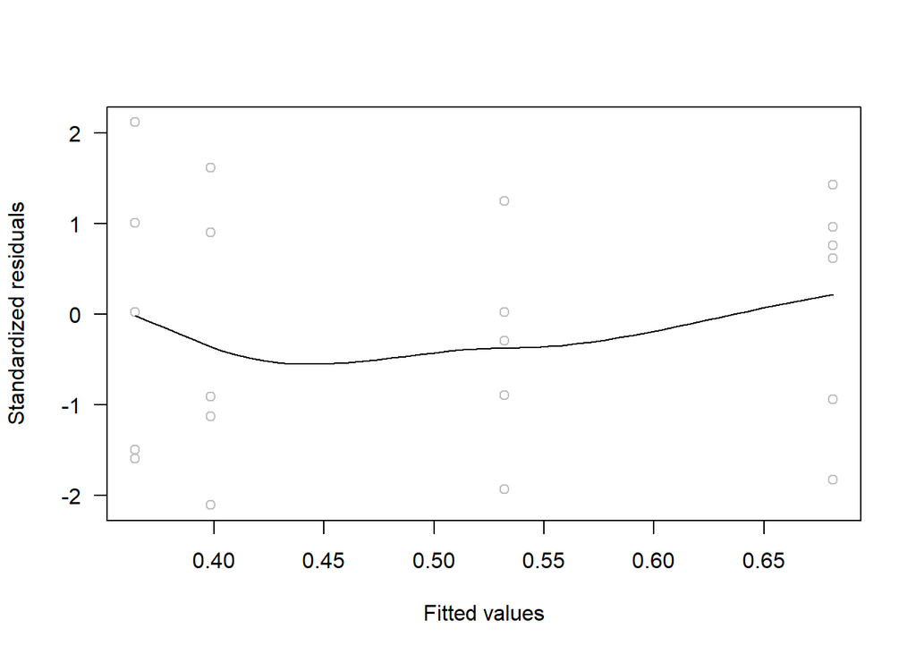

```r
# deviance residual vs fitted values
scatter.smooth( qres ~ fitted( gm.m1 ),
                col="grey", las=1,
                ylab="Standardized residuals",
                xlab="Fitted values")
```

```r
gm.od <- update(gm.m1, family=quasibinomial)
anova(gm.od, test="F")
```

```
## Analysis of Deviance Table
##
## Model: quasibinomial, link: logit
##
## Response: Germ/Total
##
## Terms added sequentially (first to last)
##
##
##               Df Deviance Resid. Df Resid. Dev       F    Pr(>F)
## NULL                             20     98.719
## Seeds          1    2.544        19     96.175  1.3665   0.25854
## Extract        1   56.489        18     39.686 30.3407 3.839e-05 ***
## Seeds:Extract  1    6.408        17     33.278  3.4418   0.08099 .
## ---
## Signif. codes:  0 '***' 0.001 '**' 0.01 '*' 0.05 '.' 0.1 ' ' 1
```

The binomial and quasi-binomial glms give identical coefficient estimates, but the standard errors from the quasi-binomial GLM are $\sqrt{\phi}$ times those from the binomial model:

```r
sqrt(summary(gm.od)$dispersion)
```

```
## [1] 1.36449
```

```r
beta <- coef(summary(gm.m1))[,"Estimate"]
m1.se <- coef(summary(gm.m1))[,"Std. Error"]
od.se <- coef(summary(gm.od))[,"Std. Error"]
data.frame(Estimate=beta, Binom.SE=m1.se,
           Quasi.SE=od.se, Ratio=od.se/m1.se)
```

```
##                             Estimate  Binom.SE  Quasi.SE   Ratio
## (Intercept)               -0.4122448 0.1841784 0.2513095 1.36449
## SeedsOA75                 -0.1459269 0.2231659 0.3045076 1.36449
## ExtractCucumber            0.5400782 0.2498130 0.3408672 1.36449
## SeedsOA75:ExtractCucumber  0.7781037 0.3064332 0.4181249 1.36449
```

## No goodness-of-fit for binary data

For binary data, likelihood ratio tests and score tests should be used, making sure that p’ is much smaller than n.

# Models for counts

## Example

- A study of the habitats of the noisy miner (a small but aggressive native Australian bird) counted the number of noisy miners y and the number of eucalypt trees x in two-hectare buloke woodland transects. Buloke woodland patches with more eucalypts tend to have more noisy miners
  - The number of noisy miners is more variable where more eucalypts are present. Between 0 and 10 eucalypts, the number of noisy miners is almost always zero; between 10 and 20 eucalypts, the number of noisy miners increases. This shows that the systematic relationship between the number of eucalypts and the number of noisy miners is not linear.
  - Between 0 and 10 eucalypts, the number of noisy miners varies little. Between 10 and 20 eucalypts, a larger amount of variation exists in the number of noisy miners. This shows that the randomness does not have constant variance.
  - the variation in the data may be modelled using a Poisson distribution.
  - A possible model for the systematic component is $\log \mu = \beta_0+\beta_1x$, where x is the number of eucalypt trees at a given site, and μ is the expected number of noisyminers.

$$\begin{cases}
y \sim \text{Pois}(\mu) \quad (\text{random component}) \\
\log\mu=\beta_0+\beta_1x \quad (\text{systematic component})
\end{cases}$$

## introduction & model summary

Poisson distribution is used to model counts, which has PMF:
$$\mathcal{P}(y;\lambda)=\frac{\exp(-\lambda)\lambda^y}{y!}$$
The unit deviance for Poisson distribution is:
$$d(y, \lambda)=2\{y\log\frac{y}{\lambda}-(y-\lambda)\}$$
and the residual deviance is
$$D(y,\hat{\lambda})=\sum w_i d(y_i, \hat{\lambda}_i)$$
where $w_i$ are the prior weights.

# Models for positive continuous data